### Report: act_report

# INSIGHTS FROM THE WE RATE DOG TWEETER PAGE ANALYSIS

Historical data about dog ratings tweets from the 'we rate dogs' twitter page were gathered through their tweets archive and twitter api, it was then cleaned, tidied and saved as a master dataset with the most relevant information about each tweet, the dog featured in them, the dog's rating and tweet engagement between november 2015 and august 2017 in a well detailed format.

An analysis was then run on the wrangled data that produced the insights shown and briefly explained below:

Insight 1 - According to the results obtained by getting the value counts of the dog predictions from our dataset we get to know that the most popular dog breed according to the dataset is the golden_retriever profusely followed by the Labrador_retriever.

Insight 2 - Using the pandas describe method we see clearly that the average dog rating is about **12.28** or approximately **12.3**.

Insight 3 - According to the ratings column value counts the highest rating gave by a user is **1776**.

Insight 4 - Using the counts method on the ratings we get to know that the most rated value is **12** with a count of **450**.

# SUMMARY

1. The golden retrievers are the most common dog breeds found in the tweet file followed by the labrador retriever and the pembroke, chihuahua and the rest.

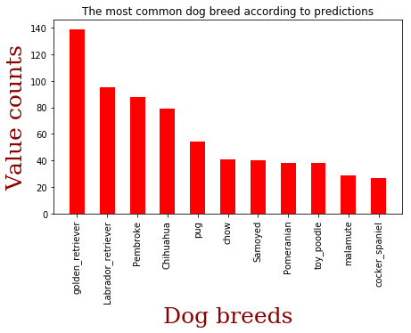

- Note: Although some of our rows contains names that doesnt belong to any dog breed like cup, doughnut etc. This occured as a result of the model used in detecting the dog image. The model detected the object that covered most of the background and gave the name of the object as that of a dog . These are one of the problems encountered and was solved by visuals instead of programmatic approach.